# Homework 5

Alexander Van Roijen

February 8, 2019

## Problem 1

```r
processData = read.csv('defects.csv')
print(names(processData))
```

```
## [1] "Sample"  "Method"  "Defects" "Weight"
```

```r
chars = c('A','B','C','D')
as = processData[processData$Method=='A',][,'Defects']
bs = processData[processData$Method=='B',][,'Defects']
cs = processData[processData$Method=='C',][,'Defects']
ds = processData[processData$Method=='D',][,'Defects']
for(i in 1:4)
{
  j = i+1
  Data1 = processData[processData$Method==chars[i],][,'Defects']
  while(j<5)
  {
    print(chars[i])
    print(chars[j])
    Data2 = processData[processData$Method==chars[j],][,'Defects']

    print(t.test(Data1,Data2,var.equal=F))
    j=j+1
  }
}
```

```
## [1] "A"
## [1] "B"
##
##  Welch Two Sample t-test
##
## data:  Data1 and Data2
## t = -3.2589, df = 101.78, p-value = 0.001521
## alternative hypothesis: true difference in means is not equal to 0
## 95 percent confidence interval:
##  -0.29941360 -0.07283865
## sample estimates:
##  mean of x  mean of y
## 0.04054054 0.22666667
##
## [1] "A"
## [1] "C"
##
##  Welch Two Sample t-test
##
## data:  Data1 and Data2
## t = -2.0919, df = 78.185, p-value = 0.03969
## alternative hypothesis: true difference in means is not equal to 0
## 95 percent confidence interval:
##  -0.286812032 -0.007106887
## sample estimates:
##  mean of x  mean of y
## 0.04054054 0.18750000
##
## [1] "A"
## [1] "D"
##
##  Welch Two Sample t-test
##
## data:  Data1 and Data2
## t = -2.7728, df = 67.717, p-value = 0.007173
## alternative hypothesis: true difference in means is not equal to 0
## 95 percent confidence interval:
##  -0.29406843 -0.04792741
## sample estimates:
##  mean of x  mean of y
```

[output cut: 28 more lines]

```
## 0.2266667 0.2115385
##
## [1] "C"
## [1] "D"
##
##  Welch Two Sample t-test
##
## data:  Data1 and Data2
## t = -0.27443, df = 113.79, p-value = 0.7843
## alternative hypothesis: true difference in means is not equal to 0
## 95 percent confidence interval:
##  -0.1975645  0.1494875
## sample estimates:
## mean of x mean of y
## 0.1875000 0.2115385
```

```r
ftest = aov(Defects ~ Method,data=processData)
print(summary(ftest))
```

```
##              Df Sum Sq Mean Sq F value Pr(>F)
## Method        3   1.57  0.5248   3.082  0.028 *
## Residuals   261  44.45  0.1703
## ---
## Signif. codes:  0 '***' 0.001 '**' 0.01 '*' 0.05 '.' 0.1 ' ' 1
```

As we can see, the F-test deems there is a significant enough differences between our population means.

However, was this test valid? We will assume there is independence between samples and within samples, however that is not garunteed. Next thing we can look at is if the data have equal variances and then finally if they have normally distributed values.

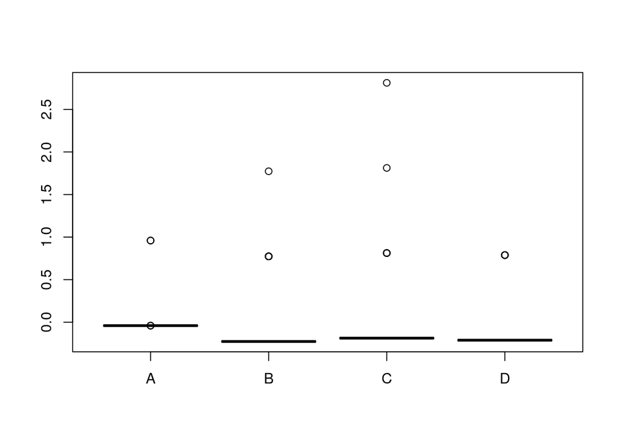

```r
boxplot(ftest$residuals~Method,data=processData)
```

```r
print(tapply(processData$Defects,processData$Method,sd))
```

```
##         A         B         C         D
## 0.1985695 0.4524209 0.5307975 0.4123837
```

The box plot doesnt help much as defects are discrete and mainly fall around zero. Looking at their standard deviations, we can see has much lower standard deviation than the rest which may indicate nonequal variances.

Now lets look at distributions of their residuals to assess our normality distribution.

```
##  [1] 0.04054054 0.04054054 0.04054054 0.04054054 0.04054054 0.04054054
##  [7] 0.04054054 0.04054054 0.04054054 0.04054054 0.04054054 0.04054054
## [13] 0.04054054 0.04054054 0.95945946 0.04054054 0.04054054 0.04054054
## [19] 0.04054054 0.04054054 0.04054054 0.04054054 0.04054054 0.04054054
## [25] 0.04054054 0.04054054 0.04054054 0.04054054 0.04054054 0.04054054
## [31] 0.04054054 0.04054054 0.04054054 0.04054054 0.04054054 0.04054054
## [37] 0.04054054 0.04054054 0.04054054 0.04054054 0.04054054 0.04054054
## [43] 0.04054054 0.04054054 0.04054054 0.04054054 0.04054054 0.04054054
## [49] 0.04054054 0.04054054 0.04054054 0.04054054 0.95945946 0.04054054
## [55] 0.04054054 0.04054054 0.04054054 0.04054054 0.04054054 0.95945946
## [61] 0.04054054 0.04054054 0.04054054 0.04054054 0.04054054 0.04054054
## [67] 0.04054054 0.04054054 0.04054054 0.04054054 0.04054054 0.04054054
## [73] 0.04054054 0.04054054
```

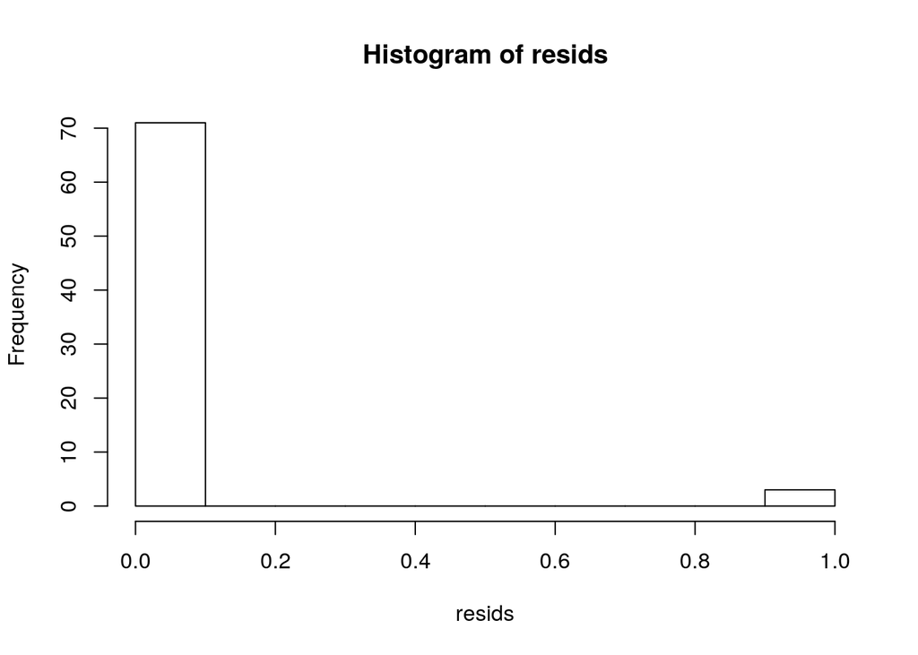

```
##  [1] 0.2266667 0.2266667 0.7733333 0.2266667 0.2266667 0.7733333 0.2266667
##  [8] 0.7733333 0.2266667 0.7733333 0.2266667 0.2266667 0.2266667 0.2266667
## [15] 0.2266667 0.2266667 0.2266667 0.2266667 0.2266667 0.2266667 0.2266667
## [22] 0.2266667 0.2266667 0.2266667 1.7733333 0.2266667 0.7733333 0.2266667
## [29] 0.2266667 0.2266667 0.2266667 0.2266667 0.2266667 0.7733333 0.7733333
## [36] 0.2266667 0.2266667 0.2266667 0.2266667 0.2266667 0.2266667 0.2266667
## [43] 0.7733333 0.2266667 0.7733333 0.2266667 0.2266667 0.2266667 0.2266667
## [50] 0.2266667 0.2266667 0.2266667 0.7733333 0.7733333 0.2266667 0.2266667
## [57] 0.7733333 0.2266667 0.2266667 0.2266667 0.7733333 0.2266667 0.2266667
## [64] 0.2266667 0.2266667 0.2266667 0.7733333 0.2266667 0.2266667 0.2266667
## [71] 0.2266667 0.7733333 0.2266667 0.2266667 0.2266667
```

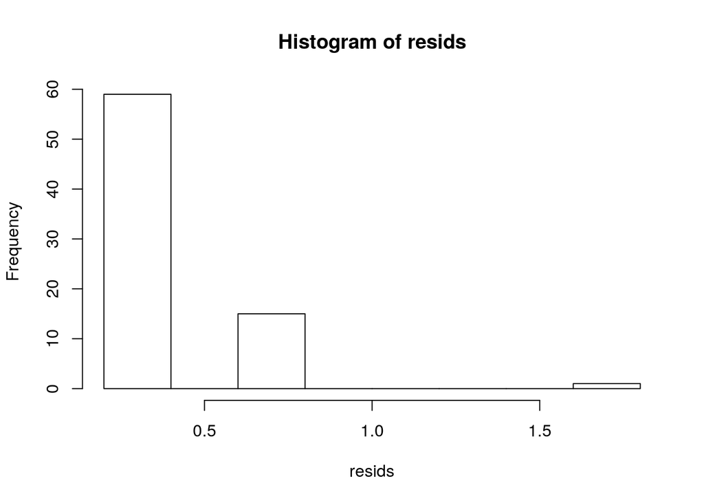

```
##  [1] 0.1875 2.8125 0.1875 0.1875 0.1875 0.1875 0.1875 0.1875 0.1875 0.1875
## [11] 0.1875 0.1875 0.1875 0.1875 0.8125 0.1875 0.1875 0.1875 0.8125 0.1875
## [21] 0.1875 0.1875 0.1875 0.1875 0.1875 0.8125 0.1875 0.1875 0.1875 0.1875
## [31] 0.1875 1.8125 0.1875 0.1875 0.8125 0.1875 0.8125 0.1875 0.1875 0.1875
## [41] 0.1875 0.1875 0.8125 0.1875 0.1875 0.1875 0.1875 0.1875 0.1875 0.1875
## [51] 0.1875 0.1875 0.1875 0.1875 0.1875 0.1875 0.1875 0.1875 0.1875 0.1875
## [61] 0.1875 0.1875 0.1875 0.8125
```

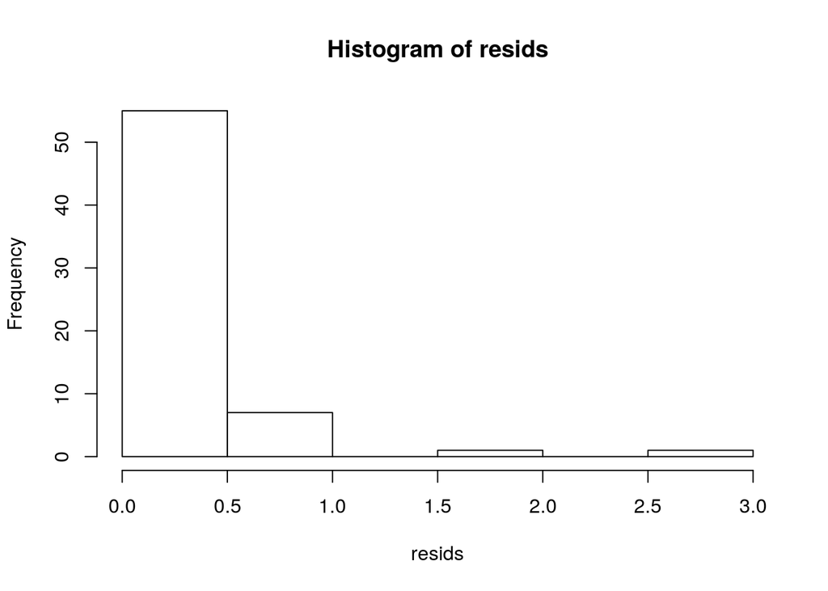

```
##  [1] 0.7884615 0.7884615 0.2115385 0.2115385 0.2115385 0.7884615 0.7884615
##  [8] 0.2115385 0.7884615 0.2115385 0.2115385 0.2115385 0.2115385 0.2115385
## [15] 0.2115385 0.2115385 0.2115385 0.2115385 0.2115385 0.2115385 0.2115385
## [22] 0.2115385 0.2115385 0.2115385 0.2115385 0.2115385 0.7884615 0.2115385
## [29] 0.2115385 0.2115385 0.7884615 0.7884615 0.2115385 0.2115385 0.2115385
## [36] 0.2115385 0.2115385 0.2115385 0.7884615 0.2115385 0.2115385 0.2115385
## [43] 0.2115385 0.2115385 0.2115385 0.2115385 0.2115385 0.2115385 0.2115385
## [50] 0.7884615 0.7884615 0.2115385
```

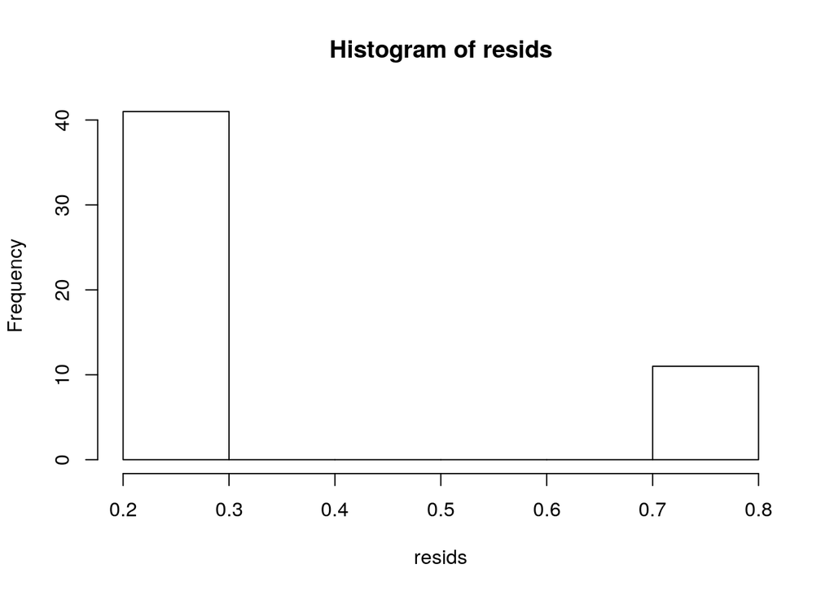

```r
residFrame = data.frame(matrix(ncol = length(chars),nrow=75))
colnames(residFrame) = chars
for(i in 1:4)
{
  j = i+1
  Data1 = c(processData[processData$Method==chars[i],][,'Defects'])
  resids = (abs(Data1-mean(Data1)))
  print(resids)
  hist(resids)
}
```

Clearly, we can see that the residuals do not follow a normal distribution, it appears to be either an exponential distribution, or perhaps a folded normal distribution. Lets simulate this to verify.

```r
numSimu = 1000
results = numeric(numSimu)
aMean = mean(as)
bMean = mean(bs)
cMean = mean(cs)
dMean = mean(ds)
asd = sd(as)
bsd = sd(bs)
csd = sd(cs)
dsd = sd(ds)
lens = tapply(processData$Defects,processData$Method,length)
alen = lens[1]
blen = lens[2]
clen = lens[3]
dlen = lens[4]
print(aMean^2)
```

```
## [1] 0.001643535
```

```r
print(aMean)
```

```
## [1] 0.04054054
```

```r
print(asd^2)
```

```
## [1] 0.03942984
```

```r
print(bMean^2)
```

```
## [1] 0.05137778
```

```r
print(bMean)
```

```
## [1] 0.2266667
```

```r
print(bsd^2)
```

```
## [1] 0.2046847
```

```r
print(cMean^2)
```

```
## [1] 0.03515625
```

```r
print(cMean)
```

```
## [1] 0.1875
```

```r
print(csd^2)
```

```
## [1] 0.281746
```

```r
print(dMean^2)
```

```
## [1] 0.04474852
```

```r
print(dMean)
```

```
## [1] 0.2115385
```

```r
print(dsd^2)
```

```
## [1] 0.1700603
```

```r
netMean = (aMean+bMean+cMean+dMean)/4
netMean = 1/netMean
print(netMean)
```

```
## [1] 6.003791
```

```r
for(i in 1:numSimu)
{
  simData = processData
  aSim = rexp(alen,aMean)
  bSim = rnorm(blen,aMean)
  cSim = rnorm(clen,aMean)
  dSim = rnorm(dlen,aMean)

  simData$Defects[simData$Method=='A']=aSim
  simData$Defects[simData$Method=='B']=bSim
  simData$Defects[simData$Method=='C']=cSim
  simData$Defects[simData$Method=='D']=dSim
  result = aov(Defects~Method,data=simData)
  store = summary(result)
  pval = store[[1]][["Pr(>F)"]][1]
  if(pval<=0.05)
  {
    results[i]=1
  }
  else
  {
    results[i]=0
  }

}
print(store)
```

```
##              Df Sum Sq Mean Sq F value Pr(>F)
## Method        3  26783    8928   63.32 <2e-16 ***
## Residuals   261  36801     141
## ---
## Signif. codes:  0 '***' 0.001 '**' 0.01 '*' 0.05 '.' 0.1 ' ' 1
```

```r
print(mean(results))
```

```
## [1] 1
```